# Question

Curve $y=f[x]$ contains points $(1,4)$ and $(3,2)$ and $(5,8)$, as shown on the $x$-$y$ plane below.

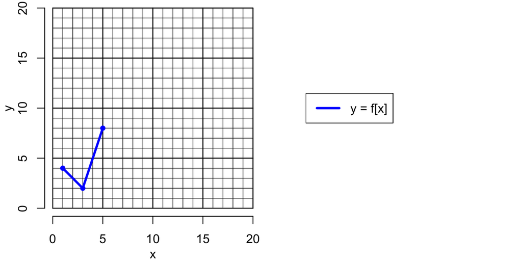

In other words:
$$f[1]=4$$
$$f[3]=2$$
$$f[5]=8$$

Let function $g$ be a transformation of function $f$, as defined by the equation below:

$$g[x]~=~2\cdot\left(f{\left[\frac{x}{3}-1\right]}+2\right)$$

Find the three corresponding points of curve $y=g[x]$.

[output not shown]

## Answerlist

- 0
- 2
- 5
- 6
- 7
- 8
- 12
- 13
- 18
- 20
- 0
- 2
- 5
- 6
- 7
- 8
- 12
- 13
- 18
- 20
- 0
- 2
- 5
- 6
- 7
- 8
- 12
- 13
- 18
- 20
- 0
- 2
- 5
- 6
- 7
- 8
- 12
- 13
- 18
- 20
- 0
- 2
- 5
- 6
- 7
- 8
- 12
- 13
- 18
- 20
- 0
- 2
- 5
- 6
- 7
- 8
- 12
- 13
- 18
- 20

# Solution

| $x$ | $g[x]$ |
| --- | --- |
| 6 | 12 |
| 12 | 8 |
| 18 | 20 |

**How to get the answers…**

Rewrite the given information:
$$f[1]=4$$
$$f[3]=2$$
$$f[5]=8$$
$$g[x]=2\cdot\left(f{\left[\frac{x}{3}-1\right]}+2\right)$$

1. Use $f[1]=4$.
   - Set the argument of $f$ equal to 1.
     $$\frac{x}{3}-1=1$$
     Solve the two-step equation.
     $$x=6$$
     Substitute 6 for $x$ in the main equation.
     $$g[6]=2\cdot\left(f{\left[\frac{6}{3}-1\right]}+2\right)$$
     Simplify the argument.
     $$g[6]=2\cdot\left(f{\left[1\right]}+2\right)$$
     Substitute 4 for $f[1]$ because $f[1]=4$.
     $$g[6]=2\cdot\left(4+2\right)$$
     Use arithmetic to evaluate the numerical expression.
     $$g[6]=12$$
     So our first new point on $y=g(x)$ is point $(6,12)$.
2. Use old point = $(3,2)$. So, use $f[3]=2$.
   - Set the argument of $f$ equal to 3.
     $$\frac{x}{3}-1=3$$
     Solve the two-step equation.
     $$x=12$$
     Substitute 12 for $x$ in the main equation.
     $$g[12]=2\cdot\left(f{\left[\frac{12}{3}-1\right]}+2\right)$$
     Simplify the argument.
     $$g[12]=2\cdot\left(f{\left[3\right]}+2\right)$$
     Substitute 2 for $f[3]$ because $f[3]=2$.
     $$g[12]=2\cdot\left(2+2\right)$$
     Use arithmetic to evaluate the numerical expression.
     $$g[12]=8$$
     So our second new point on $y=g(x)$ is point $(12,8)$.
3. Use old point = $(5,8)$. So, use $f[5]=8$.
   - Set the argument of $f$ equal to 5.
     $$\frac{x}{3}-1=5$$
     Solve the two-step equation.
     $$x=18$$
     Substitute 18 for $x$ in the main equation.
     $$g[18]=2\cdot\left(f{\left[\frac{18}{3}-1\right]}+2\right)$$
     Simplify the argument.
     $$g[18]=2\cdot\left(f{\left[5\right]}+2\right)$$
     Substitute 8 for $f[5]$ because $f[5]=8$.
     $$g[18]=2\cdot\left(8+2\right)$$
     Use arithmetic to evaluate the numerical expression.
     $$g[18]=20$$
     So our third new point on $y=g(x)$ is point $(18,20)$.

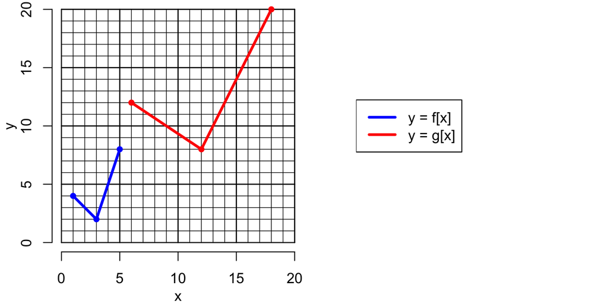

**Shortcut…**

You can save a lot of time by recognizing the following:

- The new $x$ values are found using the INVERSE of the argument expression. Remember, the expression in the argument was $\frac{x}{3}-1$, so:
  - $$x_{\text{new}}~=~3\cdot\left(x_{\text{old}}+1\right)$$
- The new $y$ values are found using the operations outside the function. It might help to see the original expression with an abbreviated argument: $2\cdot\left(f[\text{arg}]+2\right)$
  - $$y_{\text{new}}~=~2\cdot\left(y_{\text{old}}+2\right)$$

# Meta-information

extype: cloze exclozetype: schoice|schoice|schoice|schoice|schoice|schoice exsolution: 0001000000|0000001000|0000000010|0000001000|0000010000|0000000001 exname: stretch_and_shift